# 《给阿嬷的情书》票房地理扩散与观众情感分析

黄妍桐 | 广东外语外贸大学 数字经济专业

2026-07-10

## 摘要

**关键词**：空间扩散；文本挖掘；R语言；口碑传播

## 1.数据来源与处理

### 1.2 评论数据

来源：豆瓣短评（八爪鱼采集器 + 手动整理）  
时间：2026年5月30日  
有效评论数：81条  
字段：评论文本

```r
df_comm <- read_excel("电影观后感.xlsx", sheet = 1, col_names = TRUE)
colnames(df_comm) <- c("comment")
df_comm <- df_comm %>% filter(!is.na(comment), comment != "字段1")
```

## 2.票房总体表现

### 2.1累计票房走势

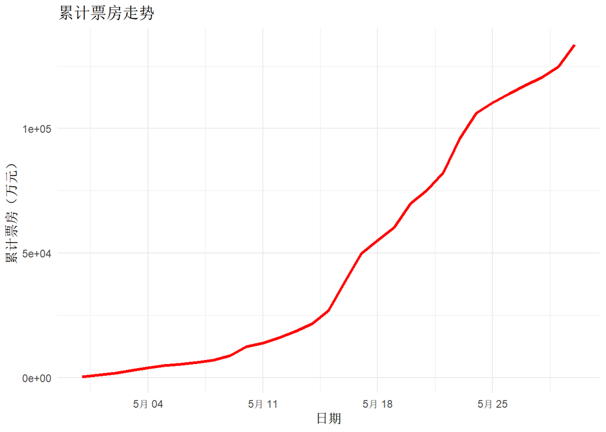

```r
df_box %>%
  mutate(cum = cumsum(national)) %>%
  ggplot(aes(x = date, y = cum)) +
  geom_line(color = "red", size = 1.2) +
  labs(title = "累计票房走势", x = "日期", y = "累计票房（万元）") +
  theme_minimal()
```

分析结论：首日仅377万元，至5月30日累计票房已突破13亿元。曲线呈典型“S型”增长，在5月16-17日（第二周周末）出现爆发式增长，体现出口碑驱动的“逆跌”特征。

### 2.2潮汕地区票房占比变化

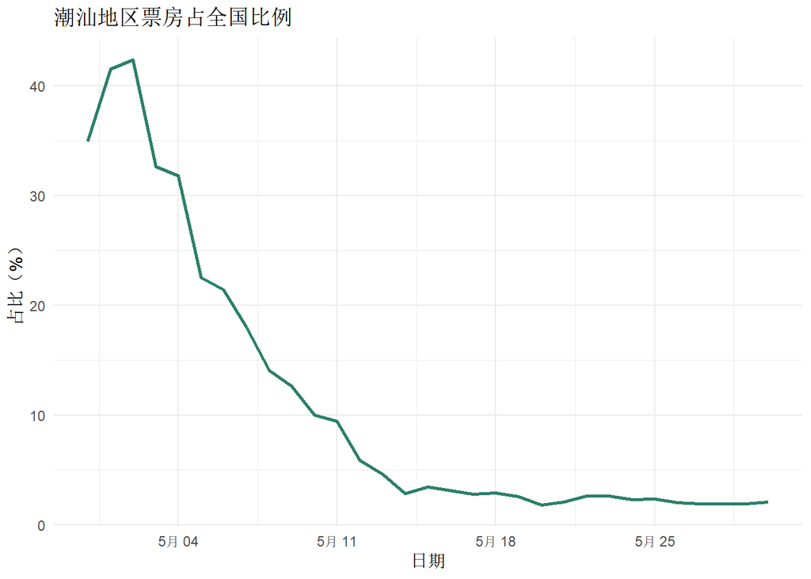

```r
df_box %>%
  mutate(ratio = chaoshan / national * 100) %>%
  ggplot(aes(x = date, y = ratio)) +
  geom_line(color = "#2C7F6B", size = 1) +
  labs(title = "潮汕地区票房占全国比例", x = "日期", y = "占比（%）") +
  theme_minimal()
```

## 3.票房地理扩散路径

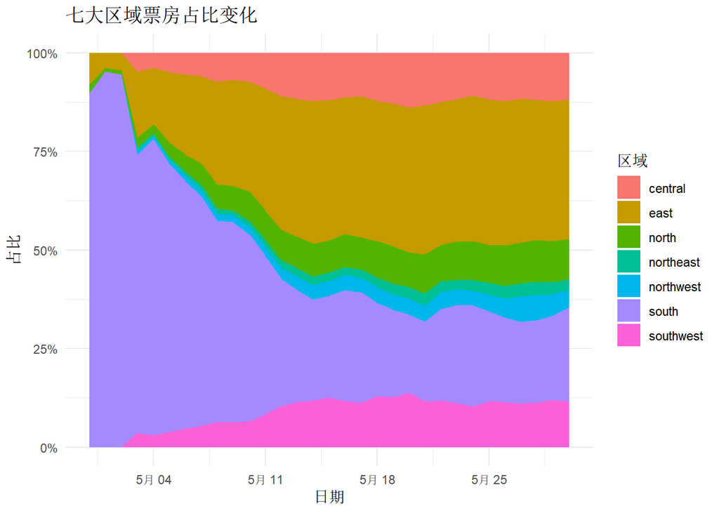

```r
region_cols <- c("east", "south", "central", "southwest", "north", "northwest", "northeast")
df_long <- df_box %>%
  select(date, all_of(region_cols)) %>%
  pivot_longer(cols = -date, names_to = "region", values_to = "box")

ggplot(df_long, aes(x = date, y = box, fill = region)) +
  geom_area(position = "fill") +
  labs(title = "七大区域票房占比变化", x = "日期", y = "占比", fill = "区域") +
  scale_y_continuous(labels = scales::percent) +
  theme_minimal()
```

## 4.豆瓣短评文本挖掘

### 4.1 词频统计与词云图

```r
# 假设 df_comm 已存在，包含 comment 列
library(dplyr)
library(stringr)
library(wordcloud2)
# 1. 把所有评论合并成一个长字符串，然后按标点分割
text_all <- paste(df_comm$comment, collapse = " ")
# 用正则表达式把中文标点、空格都替换成空格，然后按空格分割
words <- str_split(str_replace_all(text_all, "[，。？；：！、 “”‘’《》【】…—～\\.\\?\\!\\,;: \\t\\n\\r]+", " "), " ")[[1]]
words <- words[nchar(words) >= 2]   # 只保留长度>=2的词
# 2. 去除停用词（你可以继续添加）
stop_words <- c("的","了","是","我","你","他","她","它","我们","你们","他们",
                "这","那","有","就","也","还","都","在","把","被","让","给",
                "很","太","非常","特别","一个","一些","这个","那个","自己",
                "人","去","来","说","看","想","觉得","感觉","有点","还是",
                "但是","所以","因为","如果","虽然","然后","真的","电影","一部",
                "这部","片子","影片","故事","导演","演员","观众","没有","很")

words_clean <- words[!words %in% stop_words]
# 合并同义词示例
df_comm$comment <- gsub("有情有义", "情义", df_comm$comment)
df_comm$comment <- gsub("哭到崩溃", "哭", df_comm$comment)
df_comm$comment <- gsub("哭成狗", "哭", df_comm$comment)
# 可根据你的评论内容继续添加
# 3. 统计词频
word_freq <- as.data.frame(table(words_clean), stringsAsFactors = FALSE) %>%
  arrange(desc(Freq)) %>%
  head(30)
# 查看结果
word_freq
```

```
##                                           words_clean Freq
## 1                                            纸短情长    3
## 2                                                girl    2
## 3                                                友情    2
## 4                                            有情有义    2
## 5                          1960年的暹罗与1960年的汕头    1
## 6                                                23看    1
## 7                                                help    1
## 8            阿嬷听到真相后的第一句话是橄榄菜凉了没有    1
## 9                                          爱可抵万难    1
## 10                       爱情还有家国情怀足以让人动容    1
## 11                                     爱意克制又滚烫    1
## 12                                     把安稳寄回故乡    1
## 13                                     把艰辛留给自己    1
## 14                               抱着很高的期待去看的    1
```

[output cut: 16 more lines]

```r
# 4. 画词云图
wordcloud2(word_freq, size = 0.8, shape = "circle")
```

[interactive chart not shown]

### 4.2 情感定性分析

对81条评论逐条阅读后，归纳出三类主要情感倾向：  
正面（约85%）：被“有情有义”、“哭到崩溃”、“细腻真诚”等强烈打动。  
中性（约10%）：认可质量但指出节奏慢或人物过于理想化。  
负面（约5%）：认为剧情平淡、“假”或不如预期。  
典型正面评论摘录：  
“做人一定要有情有义”  
“在电影院哭成狗”  
“只有真诚才是必杀技”

## 5. 结论与建议

### 5.3 研究局限

票房数据仅覆盖前31天，未包含6月份长尾期。  
评论样本量有限（81条），情感分析未使用深度学习模型。  
未获取观众购票行为数据，无法验证“自来水”传播的直接转化率。

## 附录

附录A：票房原始数据（Excel）  
附录B：豆瓣短评原始文本（Excel）  
附录C：完整R代码（GitHub链接）